# Lab 01 - Regression Review

In this assignment you will be working with a very small data set. You need to build a regression from the ground up. I want you to focus on your understanding of the regression error term. Specifically, can you have an error term without first having a regression line?

Read pages 9-25 in the Lewis-Beck book **Applied Regression** for help.

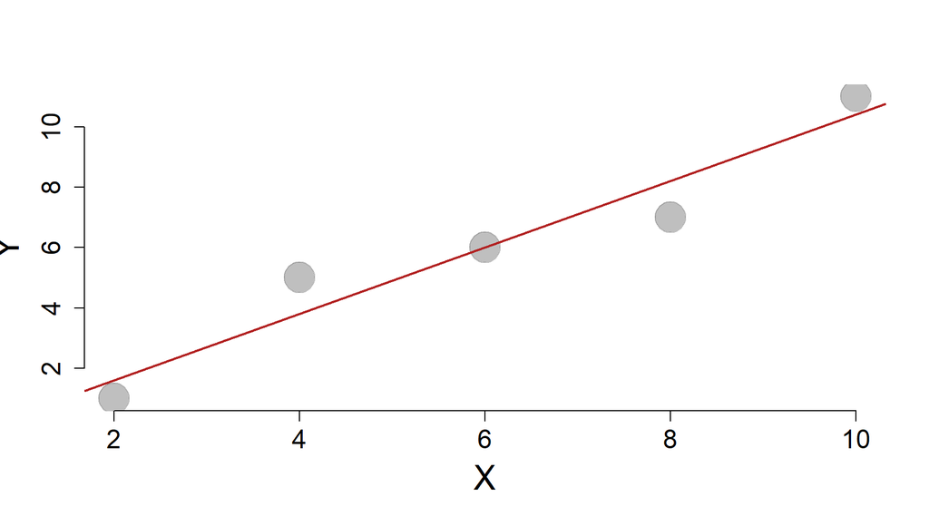

### Raw Data

| X | Y |
| --- | --- |
| 2 | 1 |
| 4 | 5 |
| 6 | 6 |
| 8 | 7 |
| 10 | 11 |

Our regression model is: $y = b_0 + b_1 x + e$

The variance/covariance of our data is:

var(x): **10**  
var(y): **13**  
cov(x,y): **11**

## Answer the following:

1. Calculate $b_1$ using the knowledge the slope can be calculated as cov(x,y) / var(x).

**ANSWER:**

2. Interpret the coefficient $b_1$ in plain English.

**ANSWER:**

3. Calculate $b_0$. Recall that the regression line always passes through the mean of X and Y:

$\bar{y} = b_0 + b_1 \bar{x}$

**ANSWER:**

4. What is the predicted value of Y when X has a value of 14?

**ANSWER:**

5. Calculate the sum of the squared errors (see page Lewis-Beck, p14).

**ANSWER:**

### Calculating the Residual

*Replace each **a** in the table with the correct value.*

| X | Y | $\hat{Y}$ | e | $e^2$ |
| --- | --- | --- | --- | --- |
| 2 | 1 | a | a | a |
| 4 | 5 | a | a | a |
| 6 | 6 | a | a | a |
| 8 | 7 | a | a | a |
| 10 | 11 | a | a | a |

6. Calculate the regression sum of squares (Lewis-Beck p21). You can check your results against the ANOVA table below.

**ANSWER:**

7. Calculate the $R^2$ using the sum of squares in the table.

**ANSWER:**

### Analysis of Variance (ANOVA) Table:

```r
library( dplyr )
library( knitr )
options( digits=2 )
m <- lm( y ~ x )
anova( m ) %>% pander()
```

Analysis of Variance Table

|  | Df | Sum Sq | Mean Sq | F value | Pr(>F) |
| --- | --- | --- | --- | --- | --- |
| **x** | 1 | 48.4 | 48.4 | 40.33 | 0.007898 |
| **Residuals** | 3 | 3.6 | 1.2 | NA | NA |

# Submission Instructions

After you have completed your lab, knit your RMD file. Login to Canvas at http://canvas.asu.edu and navigate to the assignments tab in the course repository. Upload your RMD and your HTML files to the appropriate lab submission link.

You can create a new RMarkdown file, or download the lab template: [RMD Template](https://cdn.rawgit.com/DS4PS/Data-Science-Class/c464d527/TEMPLATES/MarkdownTemplateSimple.Rmd)

Remember to:

- name your files according to the convention: **Lab-##-LastName.Rmd**
- show your solution, include your code.
- do not print excessive output (like a full data set).
- follow appropriate style guidelines (spaces between arguments, etc.).

Labs designed by Jesse D. Lecy  
Content licensed under Creative Commons: [(CC BY-NC-SA 4.0)](https://creativecommons.org/licenses/by-nc-sa/4.0/)  
Source code is available on [GitHub](https://github.com/DS4PS/cpp-523-spr-2020/tree/master/labs)  
CPP 523 [Foundations of Prog Eval I](https://ds4ps.org/cpp-523-spr-2020/)  
Part of the [MS in Evaluation and Analytics](http://ds4ps.org/ms-prog-eval-data-analytics/)  
@ [Arizona State University](https://asuonline.asu.edu/online-degree-programs/graduate/program-evaluation-and-data-analytics-ms/)